Code Recipes

# Importing Windspeed Datasets

July 17, 2022

This Code Recipe Notebook demonstrates how to import modeled windspeed datasets from Cal-Adapt into R using [caladaptR](https://ucanr-igis.github.io/caladaptr/).

# Load packages

```r
library(dplyr, quietly = TRUE)
library(sf)
library(stars)
library(caladaptr)
packageVersion("caladaptr")
```

```
[1] ‘0.6.6’
```

# Look for wind raster series

The following command doesn’t work in a Notebook, but if you run it at the console it will open up the raster series catalog in RStudio pane. You can then use the ‘Filter’ button to search for datasets which have the word ‘wind’ in the name field.

```r
# ca_catalog_rs() %>% View()
```

```r
windrs_df <- ca_catalog_search("wind")
```

```
wspeed_day_CNRM-CM5_historical
  name: daily LOCA wind speed CNRM-CM5 modeled historical
  url: https://api.cal-adapt.org/api/series/wspeed_day_CNRM-CM5_historical/
  tres: daily
  begin: 1950-01-01T00:00:00Z
  end: 2005-12-31T00:00:00Z
  units: m/s
  num_rast: 1
  id: 923
  xmin: -125.1875
  xmax: -112.75
  ymin: 30.9375
  ymax: 44.375

wspeed_day_CNRM-CM5_rcp45
  name: daily LOCA wind speed CNRM-CM5 RCP 4.5
  url: https://api.cal-adapt.org/api/series/wspeed_day_CNRM-CM5_rcp45/
  tres: daily
  begin: 2006-01-01T00:00:00Z
  end: 2100-12-31T00:00:00Z
  units: m/s
  num_rast: 1
  id: 924
  xmin: -125.1875
  xmax: -112.75
  ymin: 30.9375
  ymax: 44.375

wspeed_day_CNRM-CM5_rcp85
  name: daily LOCA wind speed CNRM-CM5 RCP 8.5
  url: https://api.cal-adapt.org/api/series/wspeed_day_CNRM-CM5_rcp85/
  tres: daily
  begin: 2006-01-01T00:00:00Z
  end: 2100-12-31T00:00:00Z
  units: m/s
  num_rast: 1
  id: 925
  xmin: -125.1875
  xmax: -112.75
  ymin: 30.9375
```

[output cut: 126 more lines]

```
  ymax: 44.375

wspeed_day_hadisd
  name: HadISD daily maximum wind speed historical observed
  url: https://api.cal-adapt.org/api/series/wspeed_day_hadisd/
  tres: daily
  begin: 1940-01-01T00:00:00Z
  end: 2021-03-31T00:00:00Z
  units: m/s
  num_rast: 1
  id: 935
  xmin: -124.5625
  xmax: -113.375
  ymin: 31.5625
  ymax: 43.75
```

View just the slugs:

```r
windrs_df$slug
```

```
 [1] "wspeed_day_CNRM-CM5_historical"   "wspeed_day_CNRM-CM5_rcp45"
 [3] "wspeed_day_CNRM-CM5_rcp85"        "wspeed_day_CanESM2_historical"
 [5] "wspeed_day_CanESM2_rcp45"         "wspeed_day_CanESM2_rcp85"
 [7] "wspeed_day_HadGEM2-ES_historical" "wspeed_day_HadGEM2-ES_rcp45"
 [9] "wspeed_day_HadGEM2-ES_rcp85"      "wspeed_day_MIROC5_historical"
[11] "wspeed_day_MIROC5_rcp45"          "wspeed_day_MIROC5_rcp85"
[13] "wspeed_day_hadisd"
```

It would appear there are raster series datasets for modelled windspeed for the first four ‘priority’ GCM models (2006-2100), as well as modeled historical data (1950-2005) (which is what you should use to compare future modeled windspeed). There is also a raster series for daily maximum wind speed historical observed (`wspeed_day_hadisd`).

# Example 1: Query Modeled Future Windspeed Data

Create an API request for future modeled wind speed. Because there isn’t a convenience function to construct an API request object for windspeed, we can use the slugs:

```r
yose_wind_cap <- ca_loc_pt(coords = c(-119.591, 37.745)) %>%
  ca_slug(c("wspeed_day_CanESM2_rcp45",
            "wspeed_day_CanESM2_rcp85",
            "wspeed_day_CNRM-CM5_rcp45",
            "wspeed_day_CNRM-CM5_rcp85",
            "wspeed_day_HadGEM2-ES_rcp45",
            "wspeed_day_HadGEM2-ES_rcp85",
            "wspeed_day_MIROC5_rcp45",
            "wspeed_day_MIROC5_rcp85")) %>%
  ca_years(start = 2070, end = 2099)

yose_wind_cap
```

```
Cal-Adapt API Request
Location(s):
  x: -119.591
  y: 37.745
Slug(s): wspeed_day_CanESM2_rcp45, wspeed_day_CanESM2_rcp85, wspeed_day_CNRM-CM5_rcp45, wspeed_day_CNRM-CM5_rcp85, wspeed_day_HadGEM2-ES_rcp45, wspeed_day_HadGEM2-ES_rcp85, wspeed_day_MIROC5_rcp45, wspeed_day_MIROC5_rcp85
Dates: 2070-01-01 to 2099-12-31
```

Pre-flight checks:

```r
yose_wind_cap %>% ca_preflight()
```

```
General issues
 - none found
Issues for querying values
 - none found
Issues for downloading rasters
 - none found
```

```r
yose_wind_cap %>% plot()
```

[interactive chart not shown]

Grab values:

```r
yose_wind_tbl <- yose_wind_cap %>%
  ca_getvals_tbl(quiet = TRUE)
```

Inspect the results:

```r
glimpse(yose_wind_tbl)
```

```
Rows: 87,656
Columns: 5
$ id   <int> 1, 1, 1, 1, 1, 1, 1, 1, 1, 1, 1, 1, 1, 1, 1, 1, 1, 1, 1, 1, 1, 1, 1, 1, 1, 1, 1, 1, 1, 1, ~
$ slug <chr> "wspeed_day_CanESM2_rcp45", "wspeed_day_CanESM2_rcp45", "wspeed_day_CanESM2_rcp45", "wspee~
$ spag <fct> none, none, none, none, none, none, none, none, none, none, none, none, none, none, none, ~
$ dt   <chr> "2070-01-01", "2070-01-02", "2070-01-03", "2070-01-04", "2070-01-05", "2070-01-06", "2070-~
$ val  [m/s] 3.364379 [m/s], 4.200935 [m/s], 3.086778 [m/s], 4.300434 [m/s], 1.532637 [m/s], 3.203793 [~
```

# Example 2: Download Modeled Windspeed Data for an Entire County as a TIF

1. Find thing is we need to find the fips code for Mono County:

```r
mono_cnty_fips <- ca_aoipreset_geom("counties", quiet = TRUE) %>%
  st_drop_geometry() %>%
  filter(grepl("Mono", name)) %>%
  pull(fips)

mono_cnty_fips
```

```
[1] "06051"
```

2. Create the API request:

```r
mono_wspeed_cap <- ca_loc_aoipreset(type = "counties",
                                        idfld = "fips",
                                        idval = "06051") %>%
  ca_slug(c("wspeed_day_CanESM2_rcp45",
            "wspeed_day_CNRM-CM5_rcp45",
            "wspeed_day_HadGEM2-ES_rcp45",
            "wspeed_day_MIROC5_rcp45")) %>%
  ca_years(start = 2070, end = 2099)

mono_wspeed_cap
```

```
Cal-Adapt API Request
Location(s):
  AOI Preset: counties
  fips(s): 06051
Slug(s): wspeed_day_CanESM2_rcp45, wspeed_day_CNRM-CM5_rcp45, wspeed_day_HadGEM2-ES_rcp45, wspeed_day_MIROC5_rcp45
Dates: 2070-01-01 to 2099-12-31
```

Preflight checks:

```r
mono_wspeed_cap %>% ca_preflight()
```

```
General issues
 - none found
Issues for querying values
 - A spatial aggregation function is required to query values from polygon areas. See `ca_options`.
Issues for downloading rasters
 - none found
```

```r
mono_wspeed_cap %>% plot(locagrid = TRUE)
```

[interactive chart not shown]

Get the data as TIFs:

```r
tiff_dir <- tools::R_user_dir("caladaptr", which = "data") %>% file.path("Mono")
if (!file.exists(tiff_dir)) dir.create(tiff_dir, recursive = TRUE)

mono_wspeed_fn <- mono_wspeed_cap %>%
  ca_getrst_stars(out_dir = tiff_dir)
```

```
 - C:\Users\Andy\AppData\Roaming/R/data/R/caladaptr/Mono/wspeed_day_CanESM2_rcp45_fips-06051.tif found. Skipping.
 - C:\Users\Andy\AppData\Roaming/R/data/R/caladaptr/Mono/wspeed_day_CNRM-CM5_rcp45_fips-06051.tif found. Skipping.
 - C:\Users\Andy\AppData\Roaming/R/data/R/caladaptr/Mono/wspeed_day_HadGEM2-ES_rcp45_fips-06051.tif found. Skipping.
 - C:\Users\Andy\AppData\Roaming/R/data/R/caladaptr/Mono/wspeed_day_MIROC5_rcp45_fips-06051.tif found. Skipping.
 - Done. Read TIFs in with `ca_stars_read`
```

```r
mono_wspeed_fn
```

```
[1] "C:\\Users\\Andy\\AppData\\Roaming/R/data/R/caladaptr/Mono/wspeed_day_CanESM2_rcp45_fips-06051.tif"
[2] "C:\\Users\\Andy\\AppData\\Roaming/R/data/R/caladaptr/Mono/wspeed_day_CNRM-CM5_rcp45_fips-06051.tif"
[3] "C:\\Users\\Andy\\AppData\\Roaming/R/data/R/caladaptr/Mono/wspeed_day_HadGEM2-ES_rcp45_fips-06051.tif"
[4] "C:\\Users\\Andy\\AppData\\Roaming/R/data/R/caladaptr/Mono/wspeed_day_MIROC5_rcp45_fips-06051.tif"
```

Read the windspeed data back in:

```r
mono_wspeed_lst <- ca_stars_read(mono_wspeed_fn)
names(mono_wspeed_lst)
```

```
[1] "wspeed_day_CanESM2_rcp45_fips-06051"    "wspeed_day_CNRM-CM5_rcp45_fips-06051"
[3] "wspeed_day_HadGEM2-ES_rcp45_fips-06051" "wspeed_day_MIROC5_rcp45_fips-06051"
```

```r
mono_wspeed_lst[[1]]
```

```
stars object with 3 dimensions and 1 attribute
attribute(s), summary of first 1e+05 cells:
                                        Min.  1st Qu.   Median     Mean  3rd Qu.     Max.  NA's
wspeed_day_CanESM2_rcp45_fips-...  0.4786911 2.296114 3.112727 3.456573 4.265478 13.90639 65269
dimension(s):
```

|  | from | to | offset | delta | refsys | point | values | x/y |
| --- | --- | --- | --- | --- | --- | --- | --- | --- |
| x | 1 | 30 | -119.688 | 0.0625 | WGS 84 | FALSE | NULL | [x] |
| y | 1 | 21 | 38.75 | -0.0625 | WGS 84 | FALSE | NULL | [y] |
| date | 1 | 10957 | 2070-01-01 | 1 days | Date | NA | NULL |  |

Plot wind speed for the first week of January for the first raster: `wspeed_day_CanESM2_rcp45_fips-06051`:

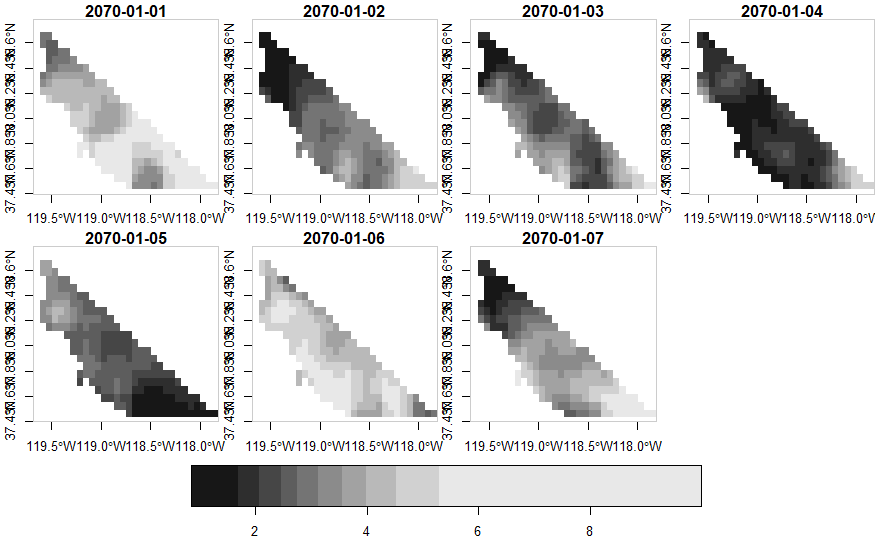

```r
plot(mono_wspeed_lst[[1]] %>% slice(index = 1:7, along = "date"),
     axes = TRUE,
     main = st_get_dimension_values(mono_wspeed_lst[[1]], "date")[1:7])
```